# Andrew Bowen DATA 607 HW 7

Andrew Bowen

2022-11-01

Using the sample code from [Chapter 2 of Text Mining with R](https://www.tidytextmining.com/sentiment.html)

```r
library(tidytext)
library(tidyr)
library(janeaustenr)
library(dplyr)
library(stringr)
library(ggplot2)
library(wordcloud)
library(reshape2)
library(glue)
```

```r
get_sentiments("afinn")
```

```
## # A tibble: 2,477 × 2
##    word       value
##    <chr>      <dbl>
##  1 abandon       -2
##  2 abandoned     -2
##  3 abandons      -2
##  4 abducted      -2
##  5 abduction     -2
##  6 abductions    -2
##  7 abhor         -3
##  8 abhorred      -3
##  9 abhorrent     -3
## 10 abhors        -3
## # … with 2,467 more rows
```

```r
get_sentiments("bing")
```

```
## # A tibble: 6,786 × 2
##    word        sentiment
##    <chr>       <chr>
##  1 2-faces     negative
##  2 abnormal    negative
##  3 abolish     negative
##  4 abominable  negative
##  5 abominably  negative
##  6 abominate   negative
##  7 abomination negative
##  8 abort       negative
##  9 aborted     negative
## 10 aborts      negative
## # … with 6,776 more rows
```

```r
get_sentiments("nrc")
```

```
## # A tibble: 13,872 × 2
##    word        sentiment
##    <chr>       <chr>
##  1 abacus      trust
##  2 abandon     fear
##  3 abandon     negative
##  4 abandon     sadness
##  5 abandoned   anger
##  6 abandoned   fear
##  7 abandoned   negative
##  8 abandoned   sadness
##  9 abandonment anger
## 10 abandonment fear
## # … with 13,862 more rows
```

```r
tidy_books <- austen_books() %>%
  group_by(book) %>%
  mutate(
    linenumber = row_number(),
    chapter = cumsum(str_detect(text,
                                regex("^chapter [\\divxlc]",
                                      ignore_case = TRUE)))) %>%
  ungroup() %>%
  unnest_tokens(word, text)
```

```r
nrc_joy <- get_sentiments("nrc") %>%
  filter(sentiment == "joy")

tidy_books %>%
  filter(book == "Emma") %>%
  inner_join(nrc_joy) %>%
  count(word, sort = TRUE)
```

```
## # A tibble: 301 × 2
##    word          n
##    <chr>     <int>
##  1 good        359
##  2 friend      166
##  3 hope        143
##  4 happy       125
##  5 love        117
##  6 deal         92
##  7 found        92
##  8 present      89
##  9 kind         82
## 10 happiness    76
## # … with 291 more rows
```

```r
jane_austen_sentiment <- tidy_books %>%
  inner_join(get_sentiments("bing")) %>%
  count(book, index = linenumber %/% 80, sentiment) %>%
  pivot_wider(names_from = sentiment, values_from = n, values_fill = 0) %>%
  mutate(sentiment = positive - negative)
```

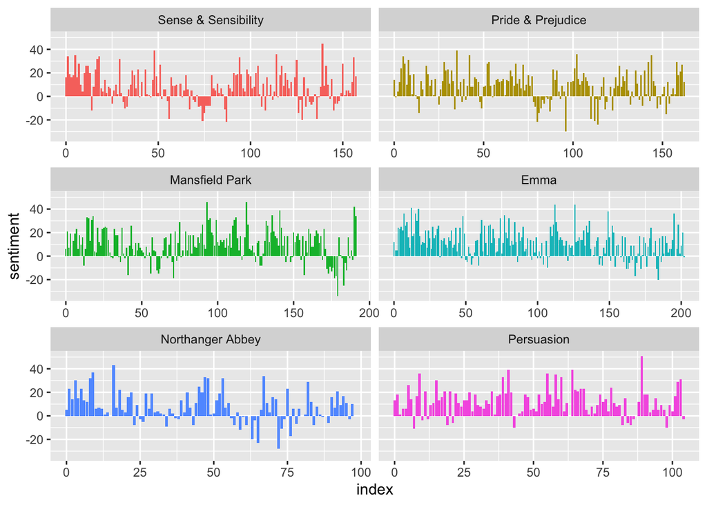

```r
# Plotting the sentiment scores
ggplot(jane_austen_sentiment, aes(index, sentiment, fill = book)) +
  geom_col(show.legend = FALSE) +
  facet_wrap(~book, ncol = 2, scales = "free_x")
```

Comparing NRC lexibon to others

```r
get_sentiments("nrc") %>%
  filter(sentiment %in% c("positive", "negative")) %>%
  count(sentiment)
```

```
## # A tibble: 2 × 2
##   sentiment     n
##   <chr>     <int>
## 1 negative   3316
## 2 positive   2308
```

```r
get_sentiments("bing") %>%
  count(sentiment)
```

```
## # A tibble: 2 × 2
##   sentiment     n
##   <chr>     <int>
## 1 negative   4781
## 2 positive   2005
```

```r
bing_word_counts <- tidy_books %>%
  inner_join(get_sentiments("bing")) %>%
  count(word, sentiment, sort = TRUE) %>%
  ungroup()
```

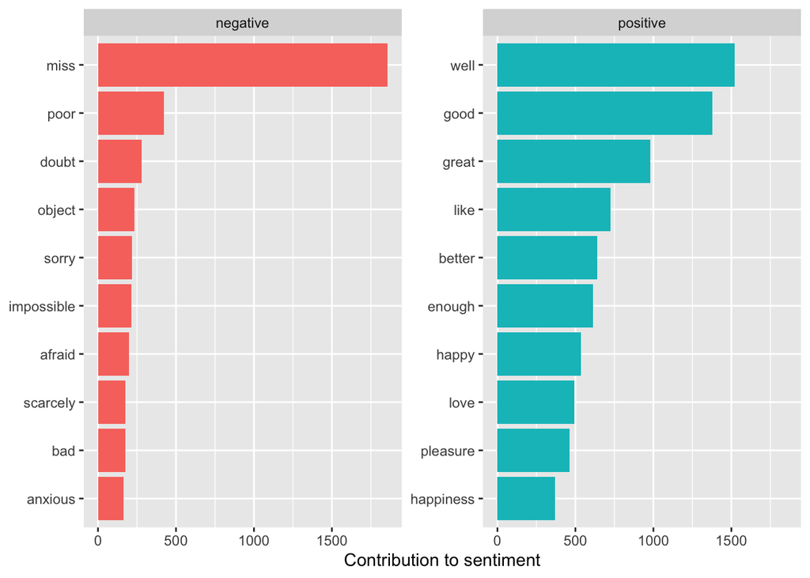

```r
bing_word_counts %>%
  group_by(sentiment) %>%
  slice_max(n, n = 10) %>%
  ungroup() %>%
  mutate(word = reorder(word, n)) %>%
  ggplot(aes(n, word, fill = sentiment)) +
  geom_col(show.legend = FALSE) +
  facet_wrap(~sentiment, scales = "free_y") +
  labs(x = "Contribution to sentiment",
       y = NULL)
```

```r
custom_stop_words <- bind_rows(tibble(word = c("miss"),
                                      lexicon = c("custom")),
                               stop_words)
```

Generating word clouds

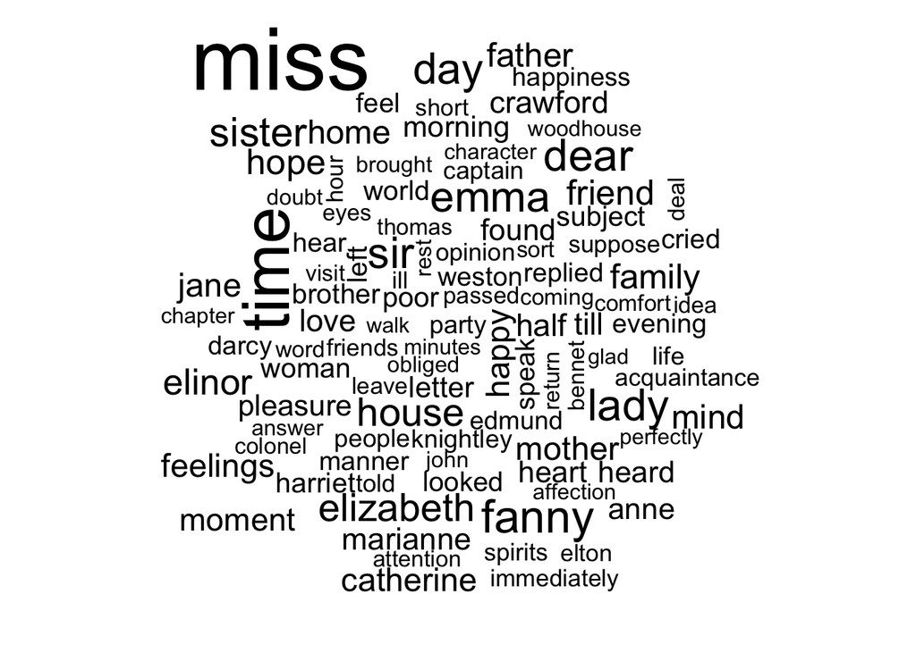

```r
tidy_books %>%
  anti_join(stop_words) %>%
  count(word) %>%
  with(wordcloud(word, n, max.words = 100))
```

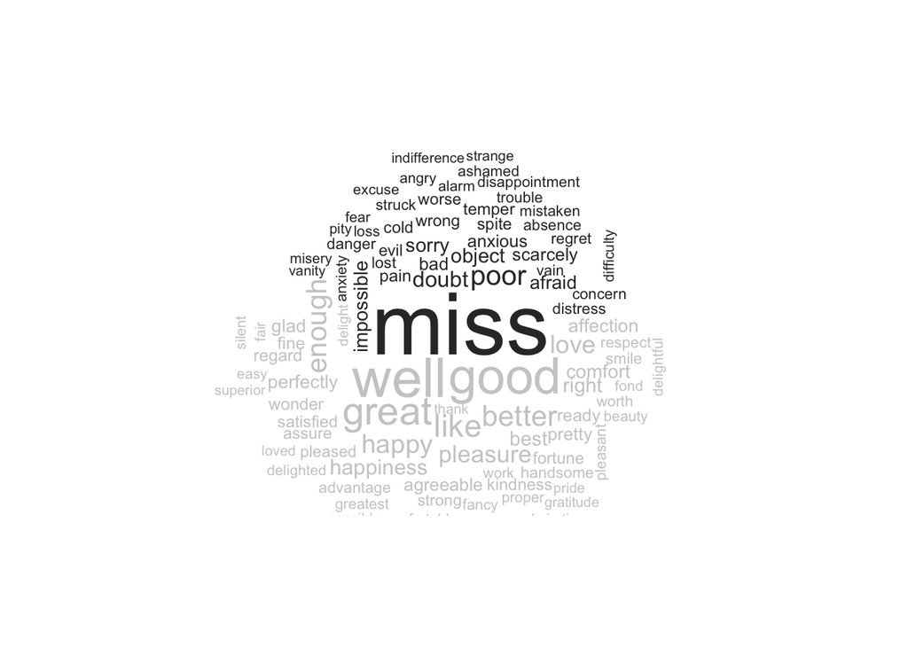

```r
tidy_books %>%
  inner_join(get_sentiments("bing")) %>%
  count(word, sentiment, sort = TRUE) %>%
  acast(word ~ sentiment, value.var = "n", fill = 0) %>%
  comparison.cloud(colors = c("gray20", "gray80"),
                   max.words = 100)
```

Now we’ll look at a sentence level rather than a word level

```r
p_and_p_sentences <- tibble(text = prideprejudice) %>%
  unnest_tokens(sentence, text, token = "sentences")

# can also split tokens via regex
austen_chapters <- austen_books() %>%
  group_by(book) %>%
  unnest_tokens(chapter, text, token = "regex",
                pattern = "Chapter|CHAPTER [\\dIVXLC]") %>%
  ungroup()

austen_chapters %>%
  group_by(book) %>%
  summarise(chapters = n())
```

```
## # A tibble: 6 × 2
##   book                chapters
##   <fct>                  <int>
## 1 Sense & Sensibility       51
## 2 Pride & Prejudice         62
## 3 Mansfield Park            49
## 4 Emma                      56
## 5 Northanger Abbey          32
## 6 Persuasion                25
```

```r
bingnegative <- get_sentiments("bing") %>%
  filter(sentiment == "negative")

wordcounts <- tidy_books %>%
  group_by(book, chapter) %>%
  summarize(words = n())
tidy_books %>%
  semi_join(bingnegative) %>%
  group_by(book, chapter) %>%
  summarize(negativewords = n()) %>%
  left_join(wordcounts, by = c("book", "chapter")) %>%
  mutate(ratio = negativewords/words) %>%
  filter(chapter != 0) %>%
  slice_max(ratio, n = 1) %>%
  ungroup()
```

```
## # A tibble: 6 × 5
##   book                chapter negativewords words  ratio
##   <fct>                 <int>         <int> <int>  <dbl>
## 1 Sense & Sensibility      43           161  3405 0.0473
## 2 Pride & Prejudice        34           111  2104 0.0528
## 3 Mansfield Park           46           173  3685 0.0469
## 4 Emma                     15           151  3340 0.0452
## 5 Northanger Abbey         21           149  2982 0.0500
## 6 Persuasion                4            62  1807 0.0343
```

## Part 1

Using a different corpus and sentiment lexicon, as well as corpus. For my corpus/dataset, I chose the [Harry Potter novels](https://uc-r.github.io/sentiment_analysis), included in the `harrypotter` library. I’ll also be using the [Jockers lexicon](https://rdrr.io/cran/lexicon/man/hash_sentiment_jockers_rinker.html) included in the `lexicon` package, which includes polarity scores as lookup values for 11,710 words.

```r
library(harrypotter)
library(sentimentr)
library(lexicon)
```

Getting Jockers lexicon into a dataframe and renaming columns for readability

```r
j_lexicon <- as.data.frame(lexicon::hash_sentiment_jockers)
j_lexicon <- j_lexicon %>%
          rename("word" = "x", "score" = "y")
```

We’ll be using the text of *Harry Potter and the Chamber of Secrets* in our example. We pulled the corpus from [this repo of .rda files](https://github.com/bradleyboehmke/harrypotter/blob/master/data/) included in the containing the text of each Harry Potter book (7 in total). Inorder to make this code reproducible, [I used the script `exxtract_hp_data.R`](https://github.com/andrewbowen19/cunyDATA607/blob/main/src/extract_hp_data.R) included in this repo to pull in the `.Rda` data and dump to csv files [hosted on my GitHub (broken out by chapter)](https://github.com/andrewbowen19/cunyDATA607/tree/main/data/harrypotter).

Each csv in the linked repo corresponds to one chapter of a book from the Harry Potter series. For instance, chapter 5 of the Chamber of Secrets would be contained in the [`chamber_of_secrets5.csv` file](https://github.com/andrewbowen19/cunyDATA607/blob/main/data/harrypotter/chamber_of_secrets5.csv)

First, let’s read in each csv file and dump them into a single dataframe, including book labels for plotting later.

```r
chapter_lengths <- c("philosophers_stone" = seq(1, 17),
                     "chamber_of_secrets" = seq(1, 19),
                     "prisoner_of_azkaban" = seq(1, 22),
                     "goblet_of_fire" = seq(1, 37),
                     "order_of_the_phoenix" = seq(1, 22),
                     "half_blood_prince" = seq(1, 30),
                     "deathly_hallows" = seq(1, 37)
                     )

# Looping over each of our chapter files within our GitHub repo
# appending each corresponding csv's dataframe to our overall one
datalist = vector("list", length = length(names(chapter_lengths)))
i <- 1
for (chapter in names(chapter_lengths)){
  url <- glue("https://raw.githubusercontent.com/andrewbowen19/cunyDATA607/main/data/harrypotter/{chapter}.csv", header=TRUE)
  book_name <- str_replace_all(chapter, "\\d{1,2}", "")
  chapter_df <- read.csv(url, sep=",",  header=TRUE) %>%
                mutate(book = book_name)

  # chapter_df$book <- seq

  datalist[[i]] <- chapter_df

  i <- i + 1

}

df <- do.call(rbind, datalist)
head(df)
```

```
##   X      word score  n               book
## 1 1 professor  0.40 30 philosophers_stone
## 2 2       yes  0.80 11 philosophers_stone
## 3 3       boy  0.25  9 philosophers_stone
## 4 4      like  0.50  9 philosophers_stone
## 5 5      well  0.80  9 philosophers_stone
## 6 6      good  0.75  7 philosophers_stone
```

Plotting our results as done above in the Jane Austen example code - these sentiment scores per word are a bit busy.

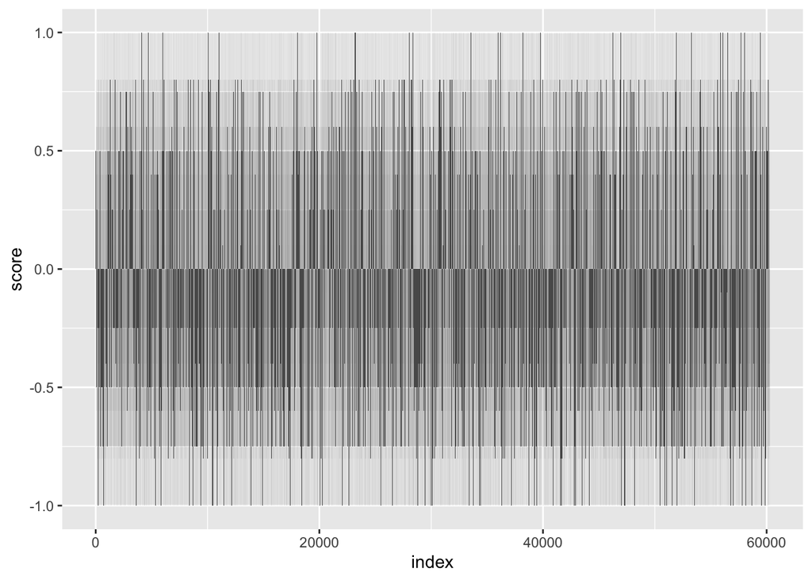

```r
df %>%
      mutate(index = row_number()) %>%
      ggplot( aes(index, score)) +
        geom_col(show.legend = FALSE)
```

Let’s re-create the above plot with the scores colored by book.

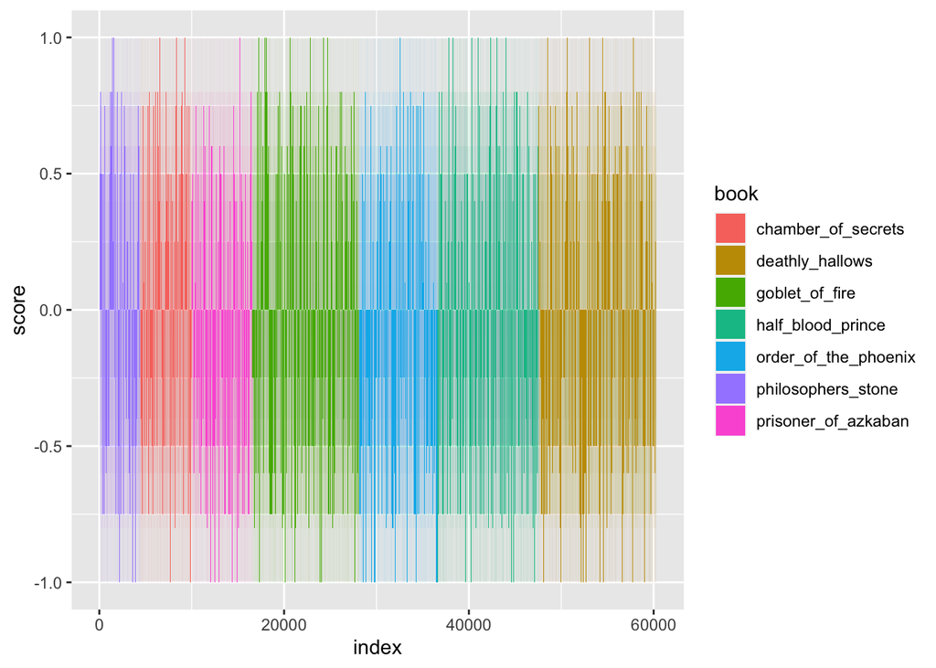

```r
df %>%
      mutate(index = row_number()) %>%
      ggplot( aes(index, score, fill=book)) +
        geom_col( )
```

Here is the same as above (sentiment scores per word per book) broken out into columns (as above)

```r
df_sentiment <- df %>%
  left_join(j_lexicon) %>%
  count(book, index = c(1:nrow(df)), score)
```

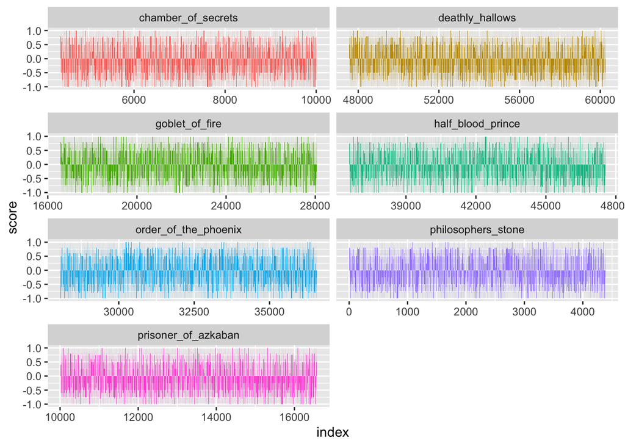

```r
# Plotting the sentiment scores
ggplot(df_sentiment, aes(index, score, fill = book)) +
  geom_col(show.legend = FALSE) +
  facet_wrap(~book, ncol = 2, scales = "free_x")
```

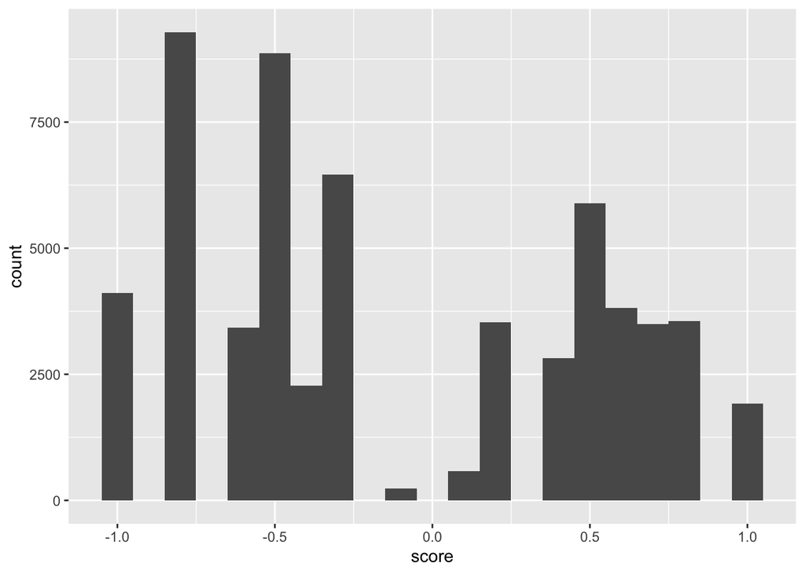

```r
ggplot(df, aes(x=score)) + geom_histogram(binwidth=0.1)
```

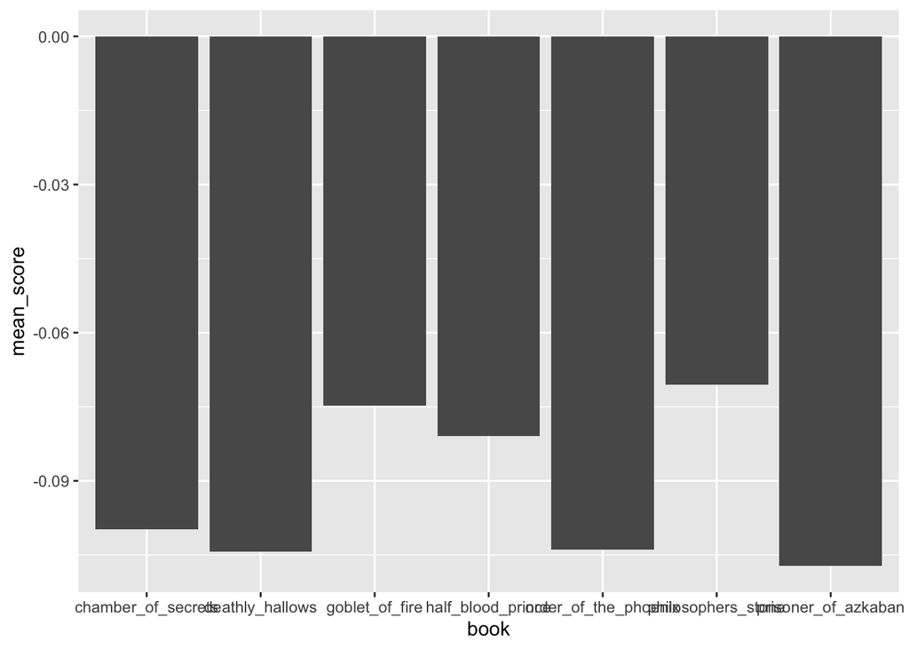

```r
df %>%
  group_by(book) %>%
  summarise(mean_score = mean(score)) %>%
  ggplot(aes(x = book, y = mean_score)) + geom_bar(stat='identity')
```

Also interested to see a scatter plot of frequency of a word vs its sentiment score, to see if any relationship exists

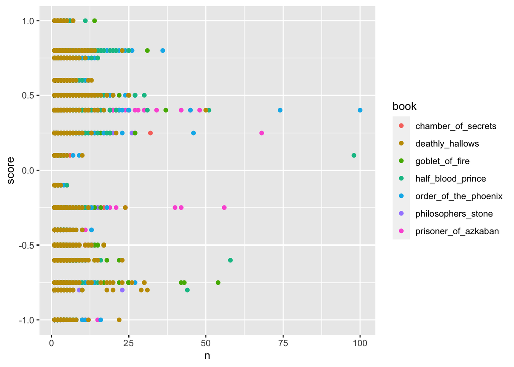

```r
ggplot(df, aes(x = n, y = score, color=book)) +
      geom_point()
```

using the built-in `cor` functionality to check for the correlation value between these two variables

```r
cor.test(df$n, df$score)
```

```
##
##  Pearson's product-moment correlation
##
## data:  df$n and df$score
## t = 22.84, df = 60252, p-value < 2.2e-16
## alternative hypothesis: true correlation is not equal to 0
## 95 percent confidence interval:
##  0.08472644 0.10055870
## sample estimates:
##        cor
## 0.09264843
```

There doesn’t appear to be a strong relationship between the two variables (correlation coeffcient $cor_n_s = 0.09$)

## Bibliography

(J. Silge 2022)

J. Silge, D Robinson. 2022. *Text Mining with r: A Tidy Approach*. https://www.tidytextmining.com/sentiment.html.